# Species Distributions

## Species composition of the biosphere

- **Intricate webs of interacting organisms**
  - ~2,200,000 species are described
  - ~17,000 new species described each year
  - estimated ~8.7 million eukaryotic species
- **Current composition reflects endless ways organisms have adapted, over and over, to a changing planet**
- **Humans have altered 75% of ice-free surface**
  - impacts livable habitats
  - impacts climate
  - impacts species diversity

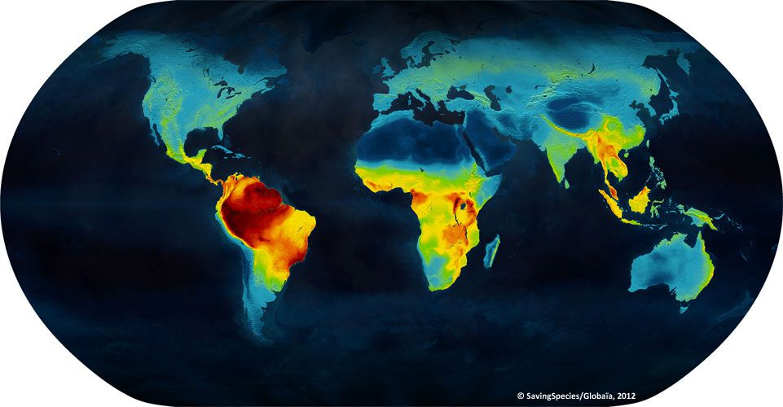

## “Essay of the geography of plants” by Humboldt, 1817

[figure not shown]

## Underlying causes of the uneven distribution of plants….

[figure not shown]

## Humboldt’s lessons: Species are spatially arranged

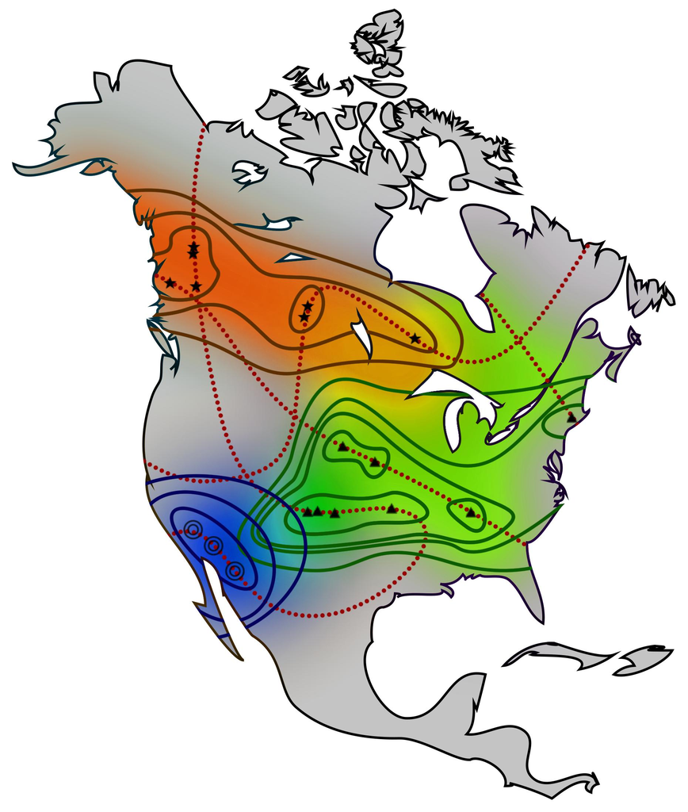

## Humboldt lessons: Species are spatially arranged

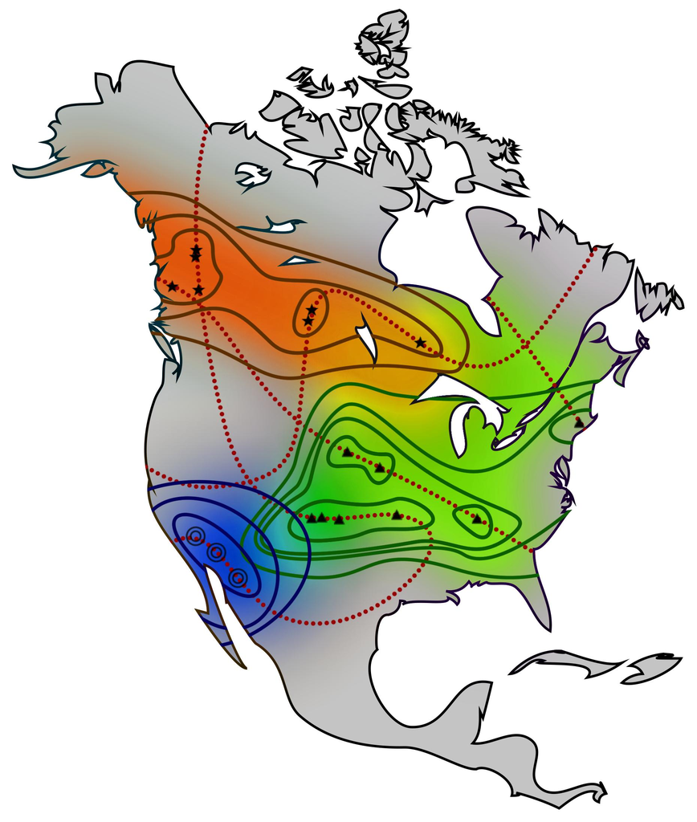

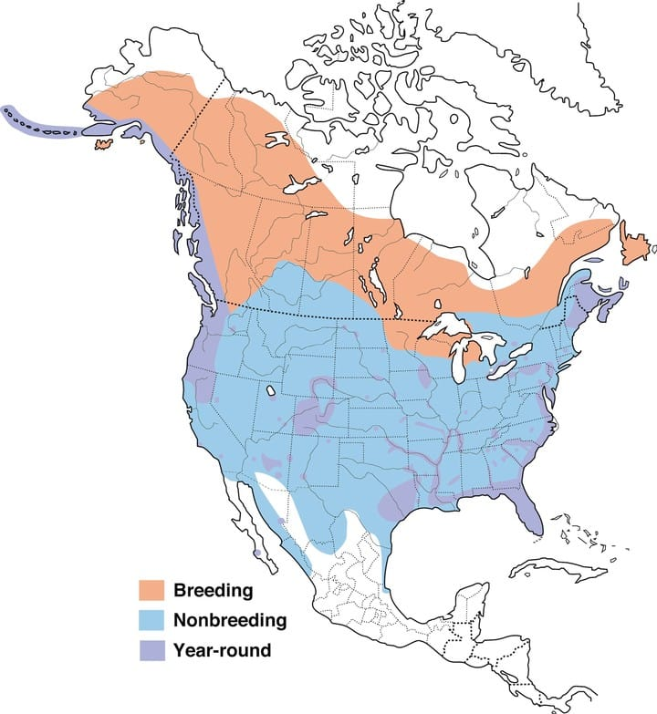

## Similar biological communities reside within shared biomes

[figure not shown]

## Climate drives broad distribution of terrestrial biomes

**Journal Club lessons: Ecotones are dynamic!!**

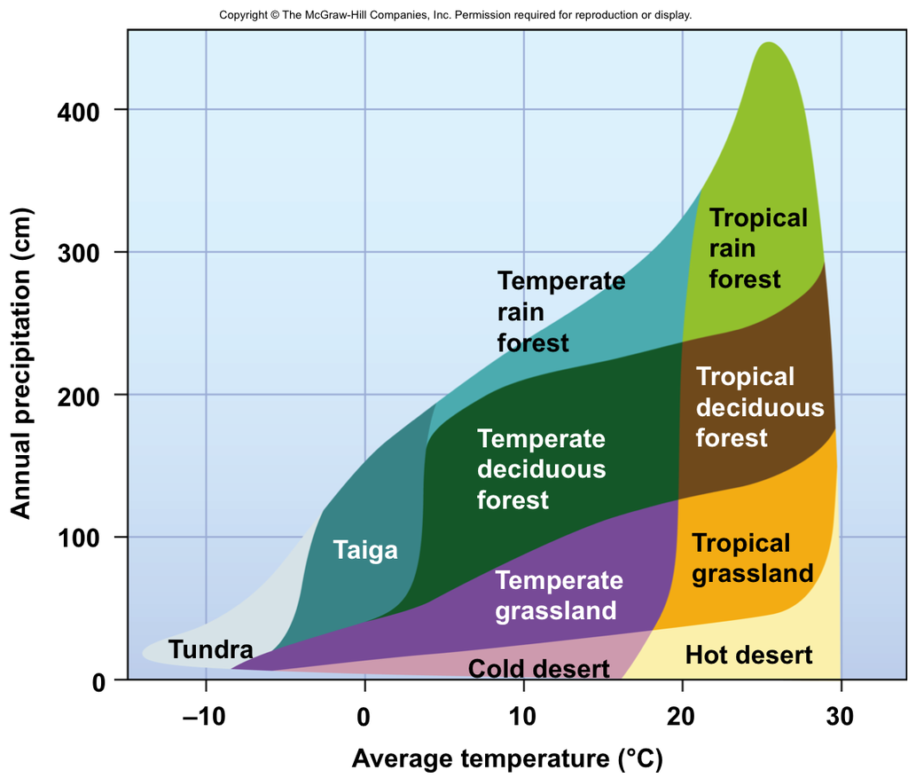

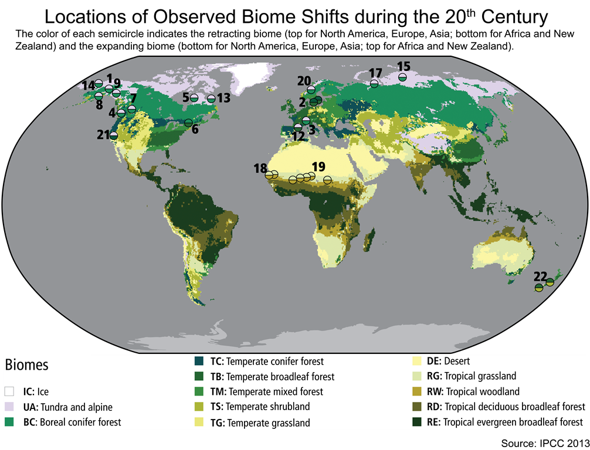

## Biomes also have distinct soil types

**Aboveground diversity (plants) are adapted to soil resources and may have evolutionary partnerships with the living soil community**

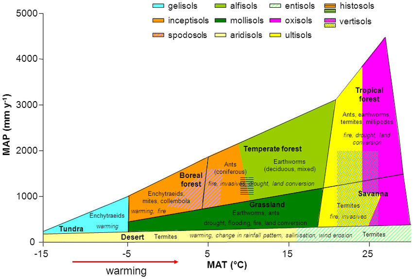

## Species distribution varies widely within biomes

**Journal Club lessons: Ecotones are dynamic,** Lecture lessons: altitude, latitude, mountains, distance from oceans, air and ocean currents…

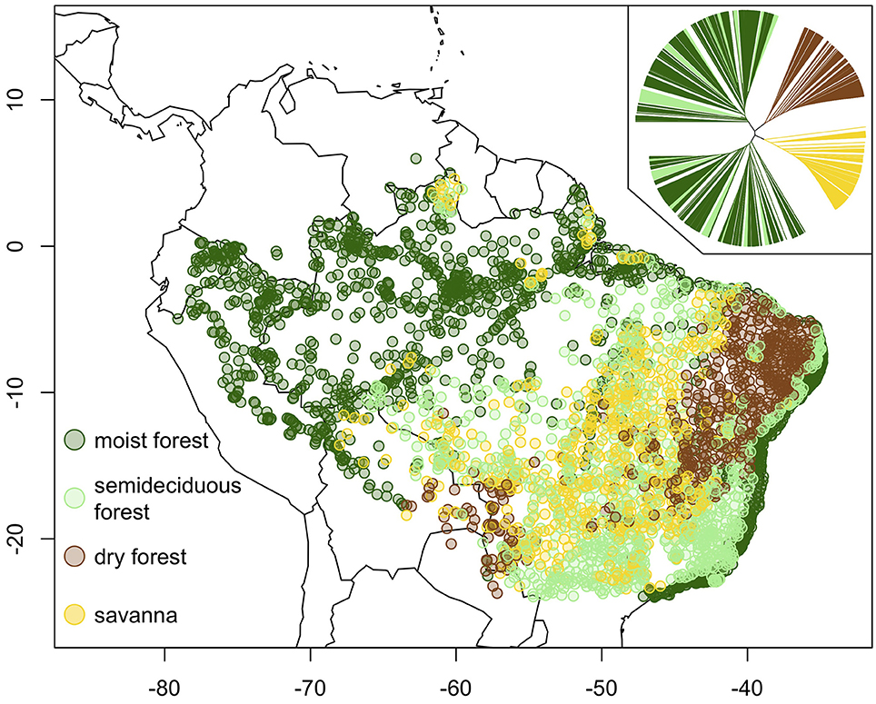

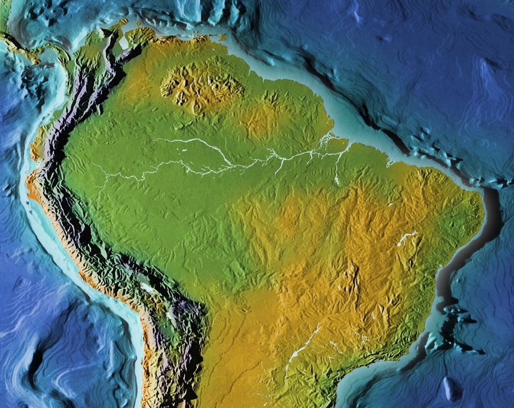

## Seasons may impact certain species distributions

[figure not shown]

## Seasonal migrations can cross biomes: Birds

[figure not shown]

## Species may instead be adapted for seasonal habitats

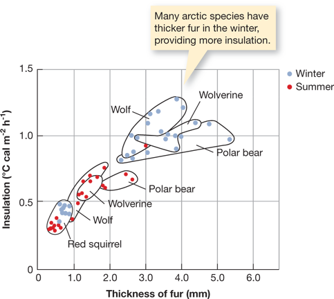

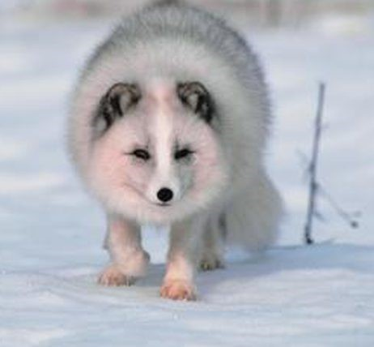

## Niche defines the limiting tolerance factors for a species

**Ecological Niche =**

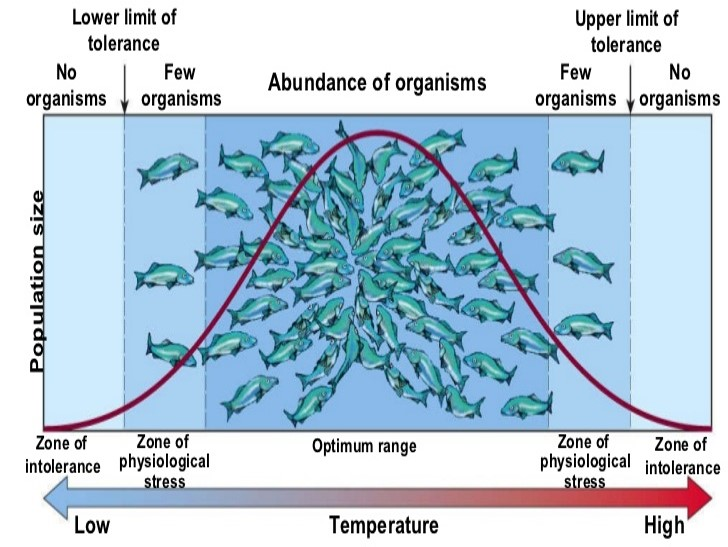

## Tolerance Ranges: Coral Reefs

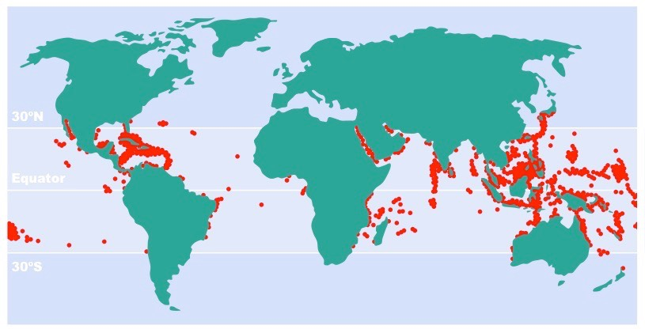

## Ecological niches exist in n-dimensions (many factors)

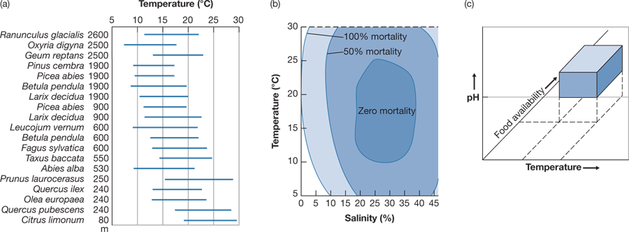

## Distribution of species within biological communities overlap

**Fundamental vs Realized Niche =**

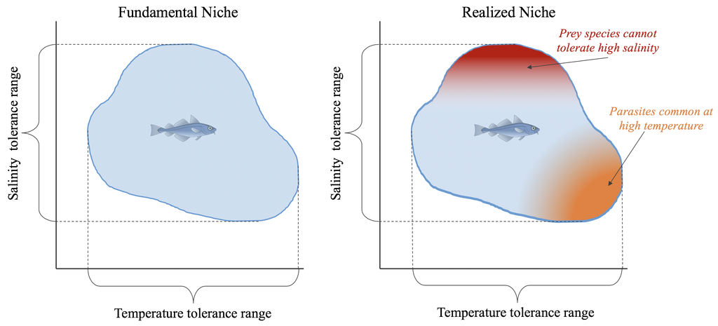

## Species distributions are related to their realized niche space

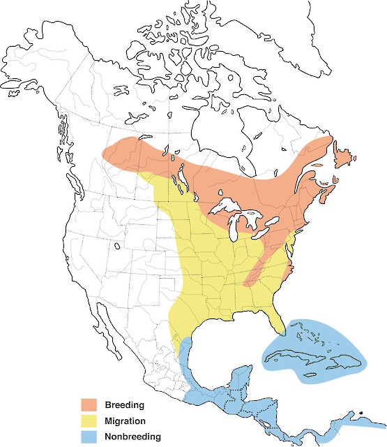

## Species distributions are related to their realized niche space

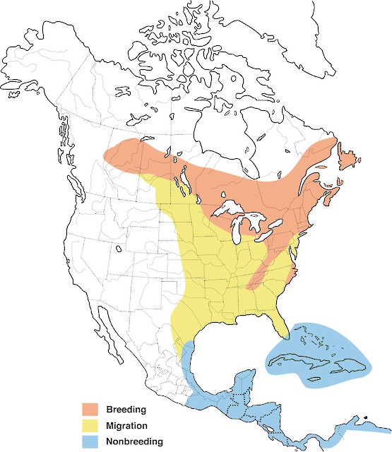

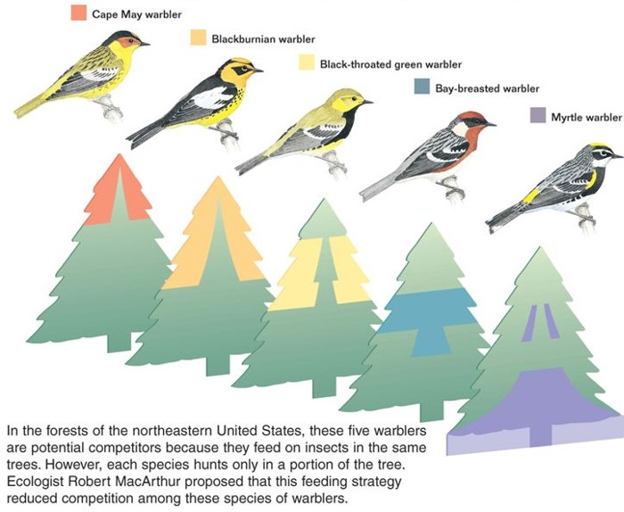

## Species ranges versus distribution: Crocodiles

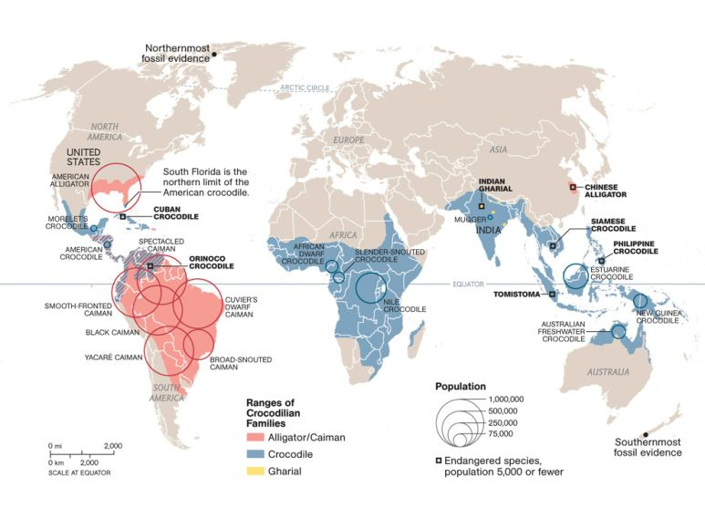

## Species ranges versus distribution: Crocodiles

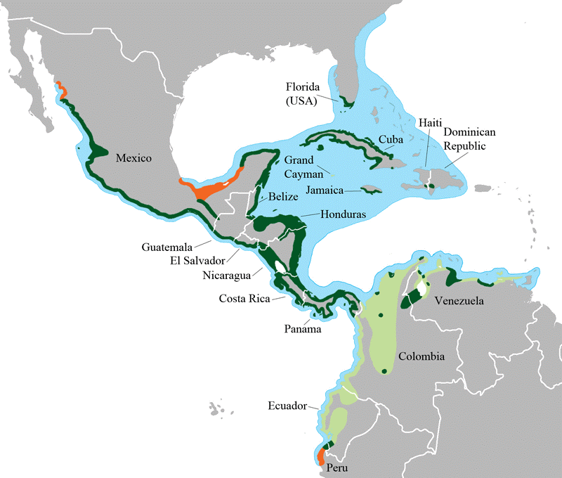

## Ranges versus distribution: Plants more limited by dispersal

**dispersal: movement of individuals or gametes**  
**seed dispersal: gravity, wind, water, and by animals**

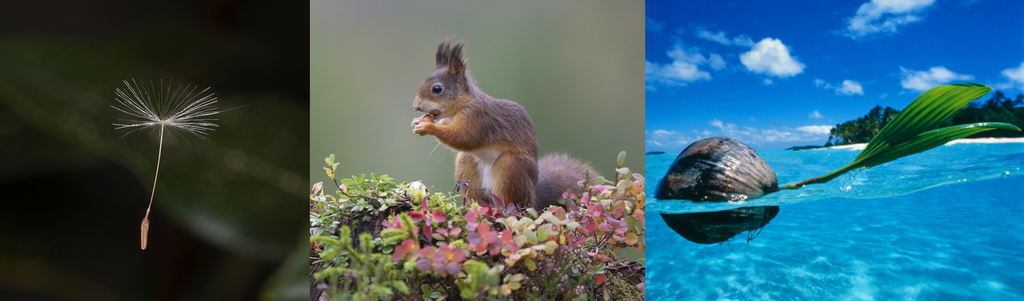

## Species ranges versus distribution: Coconut tree

[figure not shown]

## Biogeography and animal ranges: Alfred Wallace 1859

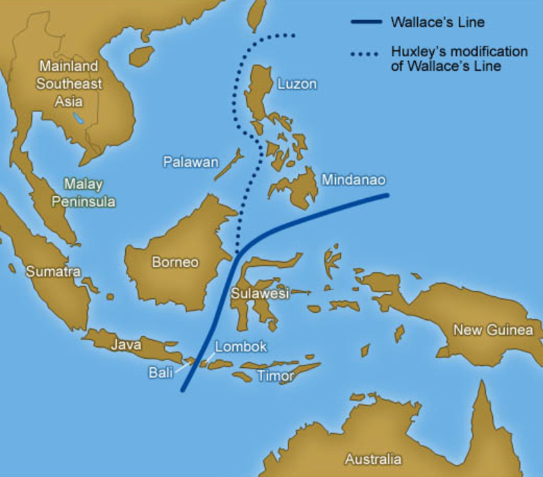

- **Wallace line is an invisible boundary separating the distinct animal species of Asia from the species of Australasia**
  - cuts a famous 20 mile gap between Bali and Lombok
- **The line represents a deep ocean channel and separation of two tectonic plates**
  - biogeographical barrier for animals
  - even during ice ages, deep water channel remained
  - many rainforst birds refuse to fly over open ocean water!
- **Wallace’s observations lead to his theory of evolution (at the same times as Darwin!)**

## Zoogeographic regions: Wallace

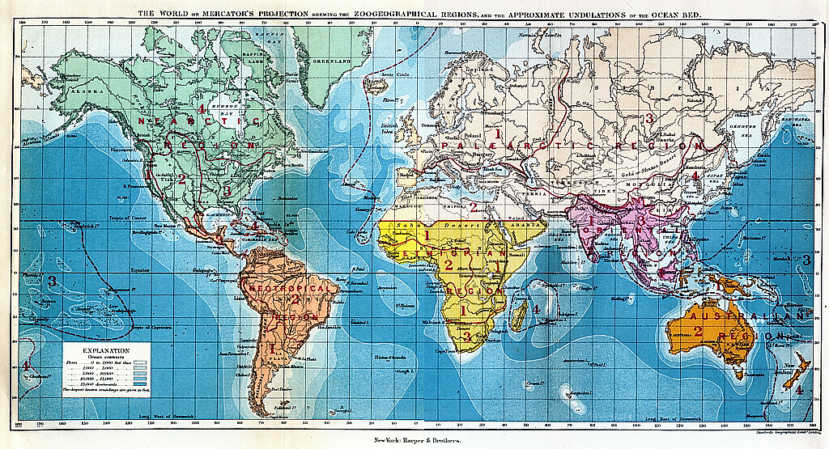

## Testable concepts in this lecture

- **Drivers of species distributions**
  - climate, biomes, soils, seasonality, and biotic interactions
- **Ecological niche and tolerance**
  - tolerance ranges, multidimensional niches, fundamental vs. realized niche
- **Species ranges and distributions**
  - potential range vs. actual distribution, dispersal, migration, and barriers
- **Biogeography and changing distributions**
  - dispersal limitations, Wallace’s zoogeographic regions